# Reproducible Research: Course Project 1

-September 2016  
*Edgar Isusquiza*

### 1. Loading and preprocessing Data

First of all, I load data from the internet Url, and then read this file as activity. Here, I present dimension and head of this data frame.

```r
setwd("G:/RespaldoEdgar/SDSH/2016 DPB/Solicitudes/R PRUEBA/Coursera/5. Reproducible Research")

fileUrl <- "https://d396qusza40orc.cloudfront.net/repdata%2Fdata%2Factivity.zip"
download.file(fileUrl, destfile ="./ActivityData.zip")
unzip('./ActivityData.zip', exdir = './ActivityData')

activity <- read.csv("./ActivityData/activity.csv")
dim(activity)
```

```
## [1] 17568     3
```

```r
head(activity)
```

```
##   steps       date interval
## 1    NA 2012-10-01        0
## 2    NA 2012-10-01        5
## 3    NA 2012-10-01       10
## 4    NA 2012-10-01       15
## 5    NA 2012-10-01       20
## 6    NA 2012-10-01       25
```

## What is mean total number of steps taken per day?

### 1.1. Calculate steps by day

In constructing the histogram for the total number of steps taken per day, I use the summarise() function to calculate the sum of the activities per day.

```r
library(dplyr)
step.day <- summarise(group_by(activity, date), steps=sum(steps))
```

### 2. Histogram of the total number of steps taken each day

In this part, I plot histogram of steps by each day taking 20 class.

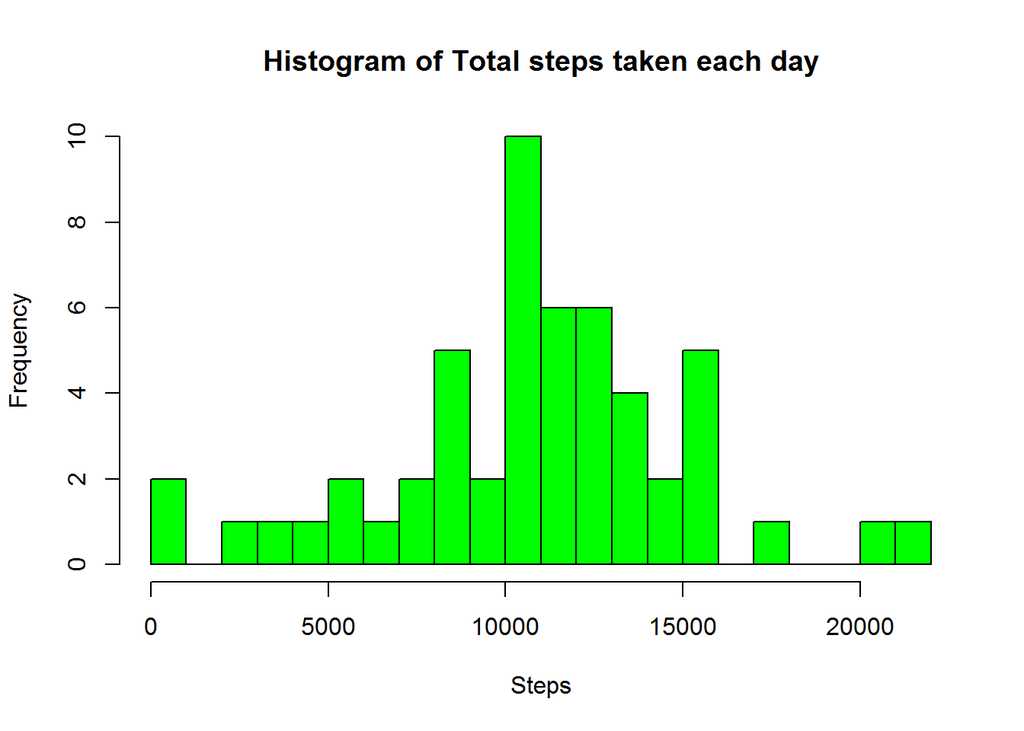

```r
hist(step.day$steps, main="Histogram of Total steps taken each day", col="green", xlab="Steps", breaks=20)
```

### 3. Calculate and report the mean and median of the total number of steps taken per day

The mean and the median for the total number of steps per day is located below.

```r
total.day1 <- summarise(group_by(activity, date), sum.steps=sum(steps))
mean(total.day1$sum.steps, na.rm=TRUE)
```

```
## [1] 10766.19
```

```r
median(total.day1$sum.steps, na.rm=TRUE)
```

```
## [1] 10765
```

## What is the average daily activity pattern?

### 4. Time series plot of the average number of steps taken

We will create the time series plot of the 5-minute interval (x-axis) and the average number of steps taken, averaged across all days (y-axis).

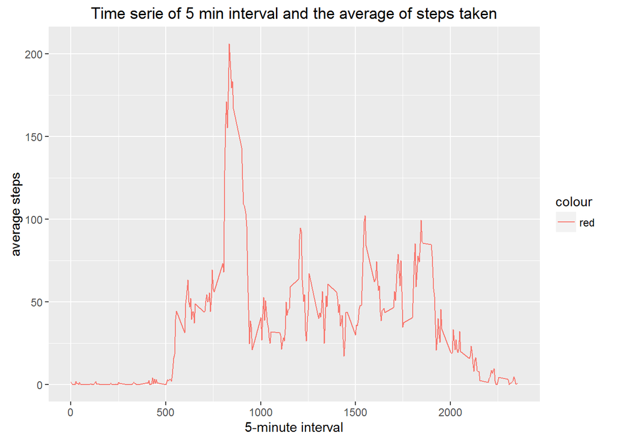

```r
library(ggplot2)
step.mean.interval <- summarise(group_by(activity, interval), mean.steps=mean(steps, na.rm=TRUE))
g <- ggplot(step.mean.interval, aes(x=interval, y=mean.steps, colour="red"))
g + geom_line()+labs(title="Time serie of 5 min interval and the average of steps taken")+labs(x="5-minute interval")+labs(y="average steps")
```

### 5. Calculating Which 5-minute interval, on average across all the days in the dataset, contains the maximum number of steps?

```r
R1 <- max(step.mean.interval$mean.steps)
R1
```

```
## [1] 206.1698
```

```r
max.step <- which.max(step.mean.interval$mean.steps)
R2 <- step.mean.interval$interval[max.step]
R2
```

```
## [1] 835
```

The answer is time interval 835 with 206.1698113 steps. First, I obtain the max value of the max value of step.mean.interval, which contains the mean of every interval. Next, I use the which.max() function to find the index of the max value of the step.mean.interval. Finally, I access the value of the value in the data frame step.mean.interval$interval.

## Imputing missing values

### 6. Imputing Missing Values

### 6.1 Total number of missing value

Here, I calculate the total missing value data in dataframe activity.

```r
sum(is.na(activity$steps))
```

```
## [1] 2304
```

### 6.2 Replace missing values

```r
activity.na <- data.frame(activity, dlsteps= is.na(activity$steps))
al <- tapply(activity$steps, activity$interval, mean, na.rm=TRUE, simplify=T)
activity.na$steps[activity.na$dlsteps] <- al[as.character(activity.na$interval[activity.na$dlsteps])]
```

```r
step.day2 <- summarise(group_by(activity.na, date), steps=sum(steps))
```

## Make a histogram with replace data

### 7.1 Adjust histogram of Total Step

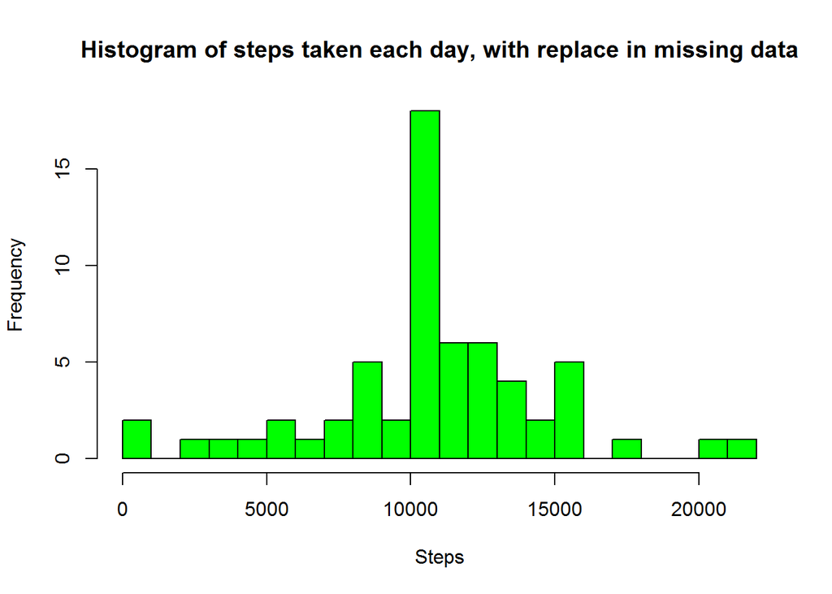

```r
hist(step.day2$steps, main="Histogram of steps taken each day, with replace in missing data", col="green", xlab="Steps", breaks=20)
```

### 7.2 Calculate mean and median with replace data

```r
total.day2 <- summarise(group_by(activity.na, date), sum.steps=sum(steps))
mean(total.day2$sum.steps, na.rm=TRUE)
```

```
## [1] 10766.19
```

```r
median(total.day2$sum.steps, na.rm=TRUE)
```

```
## [1] 10766.19
```

## Are there differences in activity patterns between weekdays and weekends?

```r
activity.na$date <- as.Date(activity.na$date)
days <- weekdays(activity.na[,2])
activity.na <- cbind(activity.na,days)
library(plyr)
activity.na$days <- revalue(activity.na$days,c("lunes"="weekday","martes"="weekday","miércoles"="weekday","jueves"="weekday","viernes"="weekday"))
activity.na$days <- revalue(activity.na$days,c("sábado"="weekend","domingo"="weekend"))
```

## Panel Plot

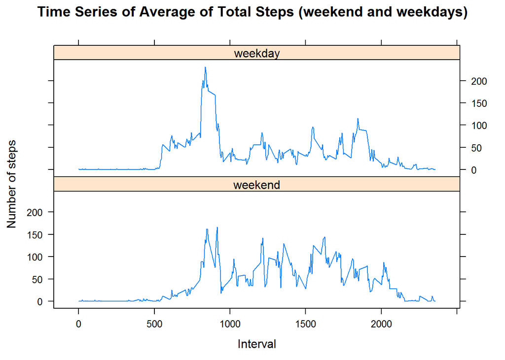

```r
wk_activity <- aggregate(steps ~ days+interval, data=activity.na, FUN=mean)
library(lattice)
xyplot(steps ~ interval | factor(days),
       layout = c(1, 2),
        xlab="Interval",
       main="Time Series of Average of Total Steps (weekend and weekdays)",
      ylab="Number of steps",
       type="l",
       lty=1,
       data=wk_activity)
```